# Question 6

Jin Barai

##### Influence

Consider a population
$$P$$
and an attribute
$$a$$
such that
$$a(P)=a(y_1,...,y_u,...,y_n)$$
Now the first thing one would wonder is how each unit affects the population? This is exactly what influence helps us to understand. We use influence to understand how and which units in a population affect a particular variate. We can know a unit’s impact on a particular variate using influence.

##### How do we calculate influence?

The influence of a unit u, on a variate a, for population could be calculated by subtracting that particular unit from the population and calculating the difference between the attribute for the populaiton without the unit, u and with the unit, u.

$$\Delta(a,u) = a(y_1,...,y_{(u-1)},y_u,y_{(u+1)},...,y_n) - a(y_1,...,y_{(u-1)},y_{(u+1)},...,y_n))$$

We use the $\Delta$ sign to denote influence.

##### Mathematical example to understand influence

In this example we will use a dataset (murders.csv) and plot the influence of the total number of murders in a state on the average of the total numbers.

Average without unit u,

$$a(y_1,...,y_{(u-1)},y_{(u+1)},...,y_n)) = ((N*\bar{y}) - y_u)/N-1$$

Using the above understanding of influence, the influence for a given u for the variate average is,

$$\Delta(a,u) = (y_u - \bar{y})/(N-1)$$

Let us first calculate delta. Here y is the column of murders in each state. We will use y to get delta.

```r
data <- read.csv("murders.csv", header = TRUE)
par(mfcol = c(1, 1))
y = data$total
N = length(y)
delta = sum(y)/N-(sum(y)-y)/(N-1)
```

Now, we will plot the influence for every unit u i.e the influence of total murders in each state on the average of total murders by y.

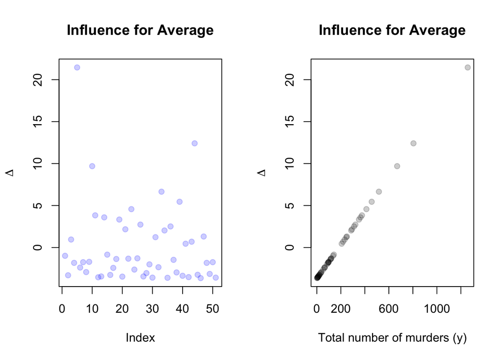

```r
par(mfrow = c(1, 2))
plot(delta, main = "Influence for Average", pch = 19, col = adjustcolor("blue",
alpha = 0.2), xlab = "Index", ylab = bquote(Delta))
plot(y, delta, main = "Influence for Average", pch = 19, col = adjustcolor("black",
alpha = 0.2), xlab = "Total number of murders (y)", ylab = bquote(Delta))
```

Hence we can see that the murders in some states have a larger impact/influence on the average number of murders. This could be due to a number of factors such as - gun laws in that particular state, quality of policing, state population etc.

##### Using influence in a real life scenario

Imagine that you actively invest in stocks. Now you purchase equal number of stocks of different companies but of equal worth, hence you invest the same money in all companies. After some years you want to know which company impacted your earnings the most (in a positive or negative way).

This is where influence helps us. If you were to calculate the influence of stocks of different companies on the average returns receieved over the years you’ll be able to understand the stocks of which company benefitted your portfolio the most and which company had no impact on your average earnings.